# Исследование результатов А/В-теста и поиск инсайтов

**Дата:** 20.09.2025

SollmaFin — международное мобильное приложение для онлайн-торговли финансовыми активами. Пользователи могут инвестировать деньги в акции, валюту, криптовалюту, биржевые фонды (ETF) и другие активы. Целевая аудитория приложения — начинающие инвесторы. Получить доступ к финансовым рынкам можно со смартфона либо через веб-версию.

Приложение ориентировано на рынок Латинской Америки с акцентом на четыре страны: Мексику, Бразилию, Колумбию и Аргентину — там быстро растёт интерес к финтеху и инвестициям, а экономики очень разные.

Появилась гипотеза о недостаточной финансовой грамотности пользователей: они не понимают, как работать с активами разной степени риска. Клиенты покупают активы с высоким риском и теряют деньги, что снижает вовлечённость. Команда продукта решила обновить онбординг пользователей и добавить в него детальную информацию о различиях финансовых активов и связанных с ними рисках. Однако появилось опасение, что углублённый онбординг отпугнёт клиентов от пополнения депозита и более рискованных вложений.

Чтобы разобраться, команда решила провести A/B-эксперимент.

### А/В-эксперимент

В эксперименте участвовали новые пользователи, которые зарегистрировались в приложении со 2 по 15 июня 2025 года. Пользователей случайным образом разделили на две равные группы:

- Контрольная группа проходила стандартный онбординг без обязательного обучения.
- Тестовая группа проходила обновлённый онбординг с подробной информацией об активах и связанных с ними рисках.

После разделения активность пользователей анализировали в течение недели.

Цель эксперимента — оценить, как обновлённый онбординг влияет на поведение пользователей и их дальнейшую инвестиционную активность.

При внедрении новой фичи команда продукта выдвинула такие гипотезы:

- Гипотеза роста: обучающий онбординг помогает пользователям лучше понимать принципы инвестирования, поэтому они будут чаще открывать второй депозит.
- Гипотеза риска: информация о возможных потерях и высоких рисках отпугнёт некоторых новичков, особенно самых осторожных, что снизит конверсию в первый депозит.
- Дополнительная гипотеза: после нового онбординга пользователи, которые выбрали высокорискованные активы, будут чаще, чем раньше, возвращаться и открывать второй депозит. При старом онбординге пользователи часто покупали активы с высоким риском без понимания последствий. Это приводило к потерям и оттоку после первого депозита.

Чтобы увидеть полную картину, недостаточно следить за метриками конверсии. Команда выбрала для эксперимента такой набор метрик:

- Ключевая метрика — средняя сумма всех депозитов на одного пользователя (включая тех, кто установил приложение или открыл веб-версию).
- Барьерная метрика — конверсия из регистрации в первый депозит.
- Вспомогательная метрика 1 — конверсия из первого депозита во второй.
- Вспомогательная метрика 2 — средняя сумма всех депозитов на пользователя, который открыл хотя бы один депозит.

Ожидалось, что ключевая и барьерная метрики не упадут, а вспомогательные покажут значительный рост.

### Задачи аналитика

Вам предстоит провести полный анализ результатов А/В-эксперимента. Но перед этим нужно погрузиться в продукт и изучить исторические данные.

#### 1. Анализ исторических данных

Чтобы понять, для чего была разработана новая фича, вам предстоит изучить исторические данные:

- Поведение новых пользователей, в том числе динамику привлечения, сегментацию и ключевые этапы воронки действий.
- Метрики, связанные с внесением депозитов, в том числе средние суммы депозитов.

#### 2. Анализ данных А/В-теста

Изучение результатов эксперимента будет состоять из двух этапов:

- Сравнение поведения пользователей в контрольной и тестовой группах, оценка статистической значимости изменений.
- Исследование влияния нового онбординга на поведение платящих пользователей. В исследовании вы будете использовать бутстрап и сосредоточитесь на нижних и верхних перцентилях распределения депозитов.
- Такой подход позволит понять, как обновлённый онбординг повлиял на ключевые бизнес-метрики, найти точки роста и сформулировать рекомендации по улучшению пользовательского опыта и монетизации.

### Данные

Вы будете работать с двумя датасетами:

1. Датасет `/datasets/pa_sollmafin_hist.csv` содержит исторические данные о ключевых действиях новых пользователей, привлечённых в период с 1 апреля по 1 июня 2025 года включительно. В датасете собраны действия пользователей до оформления второго депозита.
2. Датасет `/datasets/pa_sollmafin_abt.csv` содержит данные А/В-эксперимента — все действия новых пользователей, которые зарегистрировались со 2 по 15 июня 2025 года включительно. Данные собраны в рамках проверки гипотезы о влиянии нового онбординга на поведение и активность пользователей. Пользователи уже распределены по группам А/В-эксперимента.

Общие поля датасетов:

- `user_id` — уникальный идентификатор пользователя;
- `country_code` — код страны пользователя в формате ISO (например, `BR` — Бразилия, `MX` — Мексика, `AR` — Аргентина, `CO` — Колумбия);
- `platform` — устройство, с которого пользователь взаимодействует с продуктом: mobile или web;
- `first_ts` — время первого появления пользователя в системе;
- `first_dt` — дата первого появления пользователя (без времени);
- `event_ts` — время события;
- `event_name` — название события;
- `amount` — сумма пополнения депозита;
- `asset` — тип приобретённого актива;
- `risk_level` — уровень риска актива: low — низкий риск, medium — средний риск, high — высокий риск.

В датасете `/datasets/pa_sollmafin_abt.csv` содержатся два дополнительных поля:

- `ab_test` — название А/В-эксперимента;
- `group` — пользовательская группа А/В-эксперимента.

### План проекта

1. Загрузка исторических данных и их предобработка
2. Исследовательский анализ исторических данных
3. Исследование результатов А/В эксперимента
4. Анализ изменений суммы депозитов на платящего пользователя
5. Выводы

## Часть 1 Исторические данные

### Загрузка библиотек

```python
# Загружаем библиотеку Pandas
import pandas as pd
```

```python
# Загружаем библиотеки для визуализации данных
import matplotlib.pyplot as plt
import seaborn as sns
```

```python
# Загружаем библиотеку для диаграмм Венна
#!pip install matplotlib-venn -q
from matplotlib_venn import venn2
```

```python
import numpy as np
from scipy import stats as st
from statsmodels.stats.proportion import proportions_ztest
```

```python
# Уменьшение разрешения DPI для графиков
plt.rcParams['figure.dpi'] = 72
```

### Загрузка исторических данных и их предобработка

```python
try:
    df_hist = pd.read_csv('datasets/pa_sollmafin_hist.csv', parse_dates=['first_ts', 'first_dt', 'event_ts'])
    display(f'Файл успешно загружен  в датафрейм df_hist')
except:
    display(f'Ошибка при загрузке файла')
```

```
'Файл успешно загружен  в датафрейм df_hist'
```

Смотрим структуру данных и сами данные.

```python
display(df_hist.info())
```

```
<class 'pandas.core.frame.DataFrame'>
RangeIndex: 238059 entries, 0 to 238058
Data columns (total 10 columns):
 #   Column        Non-Null Count   Dtype
---  ------        --------------   -----
 0   user_id       238059 non-null  object
 1   country_code  238059 non-null  object
 2   platform      238059 non-null  object
 3   first_ts      238059 non-null  datetime64[ns]
 4   first_dt      238059 non-null  datetime64[ns]
 5   event_ts      238059 non-null  datetime64[ns]
 6   event_name    238059 non-null  object
 7   amount        33093 non-null   float64
 8   asset         15392 non-null   object
 9   risk_level    15392 non-null   object
dtypes: datetime64[ns](3), float64(1), object(6)
memory usage: 18.2+ MB
```

```
None
```

```python
display(df_hist.head())
```

|  | user_id | country_code | platform | first_ts | first_dt | event_ts | event_name | amount | asset | risk_level |
| --- | --- | --- | --- | --- | --- | --- | --- | --- | --- | --- |
| 0 | 548ac59f-656d-4110-80d2-49f0a217f08a | BR | mobile | 2025-04-02 19:55:51 | 2025-04-02 | 2025-04-02 19:55:51 | install / open_web | NaN | NaN | NaN |
| 1 | 548ac59f-656d-4110-80d2-49f0a217f08a | BR | mobile | 2025-04-02 19:55:51 | 2025-04-02 | 2025-04-02 19:55:59 | introduction | NaN | NaN | NaN |
| 2 | 548ac59f-656d-4110-80d2-49f0a217f08a | BR | mobile | 2025-04-02 19:55:51 | 2025-04-02 | 2025-04-02 23:46:06 | registration | NaN | NaN | NaN |
| 3 | 548ac59f-656d-4110-80d2-49f0a217f08a | BR | mobile | 2025-04-02 19:55:51 | 2025-04-02 | 2025-04-02 23:46:15 | main_page | NaN | NaN | NaN |
| 4 | 548ac59f-656d-4110-80d2-49f0a217f08a | BR | mobile | 2025-04-02 19:55:51 | 2025-04-02 | 2025-04-02 23:47:59 | onboarding_complete | NaN | NaN | NaN |

```python
#Проверим на наличие явных дубликатов в данных по всем столбцам
display(f'Явных дубликатов по всем столбцам: {df_hist.duplicated().sum()}.\
        Это {df_hist.duplicated().sum()/df_hist.shape[0]} %')
```

```
'Явных дубликатов по всем столбцам: 0.        Это 0.0 %'
```

```python
# Проверим на дубликаты пользователь + дата события + событие
display(f'Дублирующихся событий пользователь + дата события + событие: {df_hist.duplicated(subset=["user_id","event_ts","event_name"]).sum()}')
```

```
'Дублирующихся событий пользователь + дата события + событие: 0'
```

Проверим интервал дат в данных.

```python
display(f'Интервал дат "first_ts": "{df_hist["first_ts"].dt.date.min()} - {df_hist["first_ts"].dt.date.max()}')
```

```
'Интервал дат "first_ts": "2025-04-01 - 2025-06-01'
```

```python
display(f'Интервал дат "first_dt": "{df_hist["first_dt"].dt.date.min()} - {df_hist["first_dt"].dt.date.max()}')
```

```
'Интервал дат "first_dt": "2025-04-01 - 2025-06-01'
```

```python
display(f'Интервал дат "event_ts": "{df_hist["event_ts"].dt.date.min()} - {df_hist["event_ts"].dt.date.max()}')
```

```
'Интервал дат "event_ts": "2025-04-01 - 2025-06-09'
```

```python
display(f'Количество уникальных пользователей: {df_hist["user_id"].nunique()}')
```

```
'Количество уникальных пользователей: 41032'
```

```python
display(f'Уникальные страны: {df_hist["country_code"].unique()}')
```

```
"Уникальные страны: ['BR' 'AR' 'CO' 'MX']"
```

```python
display(f'Уникальные платформы: {df_hist["platform"].unique()}')
```

```
"Уникальные платформы: ['mobile' 'web']"
```

```python
display(f'Уникальные события воронки: {df_hist["event_name"].unique()}')
```

```
"Уникальные события воронки: ['install / open_web' 'introduction' 'registration' 'main_page'\n 'onboarding_complete' 'first_deposit' 'asset_purchase' 'second_deposit']"
```

```python
# Данные столбца 'amount'
display(df_hist["amount"].describe())
```

```
count    33093.000000
mean       113.527967
std         34.472458
min         27.000000
25%         90.000000
50%        109.000000
75%        131.000000
max        524.000000
Name: amount, dtype: float64
```

Построим распределение столбца депозита amount и посмотрим, как оно скошено.

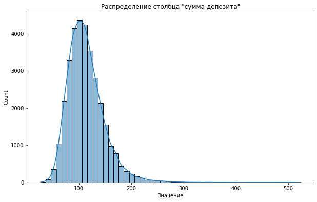

```python
plt.figure(figsize=(10, 6))
sns.histplot(df_hist['amount'], bins=50, kde=True)
plt.title('Распределение столбца "сумма депозита"')
plt.xlabel('Значение')
plt.show()
```

```python
display(f'Уникальные типы депозитов: {df_hist["asset"].unique()}')
```

```
"Уникальные типы депозитов: [nan 'stock' 'option' 'crypto']"
```

```python
display(f'Уникальные типы рисков: {df_hist["risk_level"].unique()}')
```

```
"Уникальные типы рисков: [nan 'medium' 'high' 'low']"
```

### Исследовательский анализ исторических данных

Проведем исследовательский анализ исторических данных.

#### Динамика привлечения новых пользователей в приложение по дням

**Задание** Анализ новых пользователей.

- Изучим динамику привлечения новых пользователей в приложение.

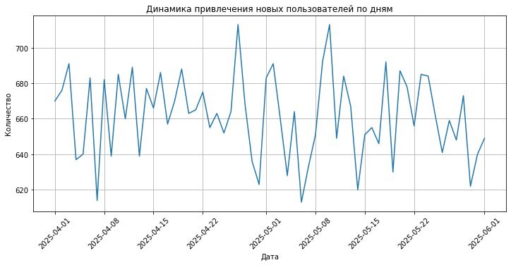

```python
# Считаем количество новых пользователей по дате первого появления в приложении
df_users_day = df_hist.groupby('first_dt')['user_id'].nunique().reset_index()
df_users_day = df_users_day.rename(columns={'user_id' : 'n_users'})

# визуализируем
plt.subplots(figsize=(12,5))

plt.plot(df_users_day['first_dt'], df_users_day['n_users'])

plt.title('Динамика привлечения новых пользователей по дням')
plt.xlabel('Дата')
plt.ylabel('Количество')
plt.xticks(rotation=45)
plt.grid()
plt.show()
```

Новые пользователи приходят каждый день, но неравномерно. Данные по новым пользователям сильно скачут из дня в день, и чтобы лучше понять общую картину, используем **скользящее среднее**. Оно сгладит резкие колебания и поможет увидеть, как меняется количество новых пользователей в целом, без резких провалов и пиков.

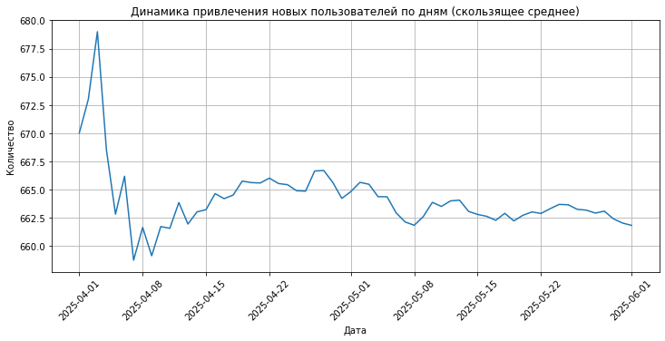

```python
# Сортируем данные по дате
df_users_day = df_users_day.sort_values('first_dt')

# Считаем количество дней
n_days=df_users_day['first_dt'].nunique()

# Считаем скользящее среднее за n_days дней
df_users_day['n_users_ma'] = df_users_day['n_users'].rolling(window=n_days, min_periods=1).mean()

# визуализируем скользящее среднее
plt.subplots(figsize=(12,5))
plt.plot(df_users_day['first_dt'], df_users_day['n_users_ma'])

plt.title('Динамика привлечения новых пользователей по дням (скользящее среднее)')
plt.xlabel('Дата')
plt.ylabel('Количество')
plt.xticks(rotation=45)
plt.grid()
plt.show()
```

**Вывод:** Привлечение новых пользователей было на пике в самом начале и стабильно во время всего периода.

#### Кумулятивная динамика привлечения новых пользователей в приложение по дням

Посмотрим на тренд привлечения новых пользователей.

```python
# Сортируем по возрастанию даты первого посещения
df_users_day = df_users_day.sort_values(by='first_dt')
```

```python
# Считаем количество пользователей нарастающим итогом
df_users_day['cumsum_users'] = df_users_day['n_users'].cumsum()
```

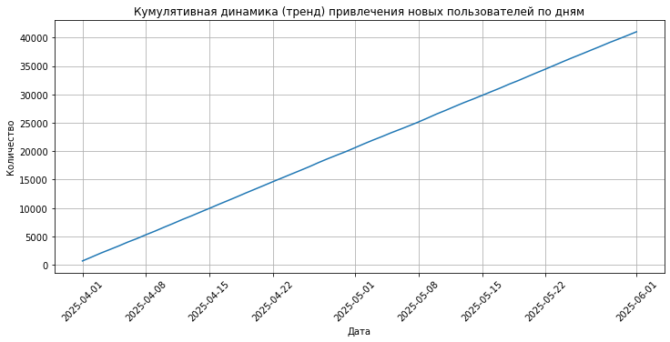

```python
# визуализируем
plt.subplots(figsize=(12,5))

plt.plot(df_users_day['first_dt'], df_users_day['cumsum_users'])

plt.title('Кумулятивная динамика (тренд) привлечения новых пользователей по дням')
plt.xlabel('Дата')
plt.ylabel('Количество')
plt.xticks(rotation=45)
plt.grid()
plt.show()
```

**Вывод:** Тренд - равномерный рост количества новых пользователей по ~ 5000 в неделю. Хорошие темпы роста.

#### Анализ классической воронки

**Задача** Анализ воронок событий.

- Построим классическую и пошаговую воронки;
- Охарактеризуем пользовательский путь в приложении и определим узкие места воронки.

```python
# Задаем порядок шагов в воронке
funnel_steps = ['install / open_web','introduction','registration','main_page','onboarding_complete',\
                'first_deposit','asset_purchase','second_deposit']
```

Видим, что в воронке 8 последовательных событий.

```python
# Считаем число уникальных пользователей на каждом шаге
funnel_counts = df_hist.groupby('event_name')['user_id'].nunique().reindex(funnel_steps)
```

```python
# Собираем таблицу воронки
funnel_df = pd.DataFrame({
   'step': pd.Series(funnel_counts.index),
   'users': pd.Series(funnel_counts.values)})
```

```python
# Добавляем конверсии и округляем до 1 знака после запятой
funnel_df['conversion_from_first_%'] = round((funnel_df['users'] / funnel_df['users'].iloc[0]) *100, 1)
```

```python
display(funnel_df.head(8))
```

|  | step | users | conversion_from_first_% |
| --- | --- | --- | --- |
| 0 | install / open_web | 41032 | 100.0 |
| 1 | introduction | 41032 | 100.0 |
| 2 | registration | 38133 | 92.9 |
| 3 | main_page | 35040 | 85.4 |
| 4 | onboarding_complete | 34337 | 83.7 |
| 5 | first_deposit | 27685 | 67.5 |
| 6 | asset_purchase | 15392 | 37.5 |
| 7 | second_deposit | 5408 | 13.2 |

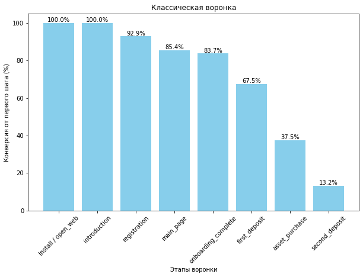

```python
# Визуализируем классическую воронку
plt.figure(figsize=(10, 6))

bars = plt.bar(funnel_df['step'], funnel_df['conversion_from_first_%'], color='skyblue')

for bar in bars:
    yval = bar.get_height() # высота столбца=значение
    plt.text(bar.get_x() + bar.get_width()/2, yval, f'{yval}%', verticalalignment='bottom', horizontalalignment='center')
    # комментарий для себя: можно также писать va= ha=

    plt.title('Классическая воронка')
plt.ylabel('Конверсия от первого шага (%)')
plt.xlabel('Этапы воронки')
plt.xticks(rotation=45)
plt.show()
```

**Вывод:** По классической воронке количество пользователей уменьшается неравномерно. До последнего шага воронки - второго депозита - доходит только 13,2% пользователей от первоначального количества. Значительное уменьшение наблюдается на трех шагах:

- шаг из "завершения онбординга" в "первый депозит" - теряется 16,2%
- шаг из "первого депозита" в "покупку актива" - теряется 30,0%
- шаг из "покупки актива" во "второй депозит" - теряется 24,3% пользователей.

#### Анализ пошаговой воронки (step-by-step)

```python
# Рассчитываем пошаговую воронку
funnel_df['conversion_from_previous_%'] = round(funnel_df['users'] / funnel_df['users'].shift(1) * 100,1)
```

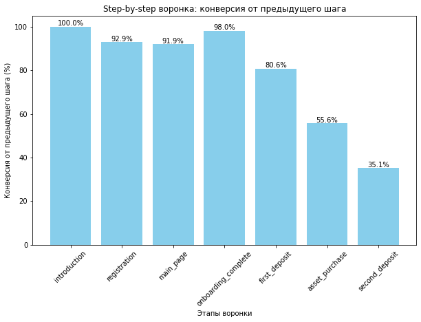

```python
# Визуализируем воронку step-by-step
funnel_df = funnel_df.iloc[1: ] # чтобы не отображать самый первый шаг с Nan

plt.figure(figsize=(10, 6))

bars = plt.bar(funnel_df['step'], funnel_df['conversion_from_previous_%'], color='skyblue')

for bar in bars:
    yval = bar.get_height() # высота столбца=значение
    plt.text(bar.get_x() + bar.get_width()/2, yval, f'{yval}%', verticalalignment='bottom', horizontalalignment='center')

plt.title('Step-by-step воронка: конверсия от предыдущего шага')
plt.ylabel('Конверсия от предыдущего шага (%)')
plt.xticks(rotation=45)
plt.xlabel('Этапы воронки')
plt.show()
```

Также обращает внимание, что 7,1% пользователей теряется после просмотра "введения" при переходе к "регистрации". Возможно, проблема возникает из-за неудачного интерфейса.

#### Анализ уровня риска актива на открытие второго депозита

**Задача** Влияние уровня риска актива на открытие второго депозита.

- Изучим, как уровень риска первого актива влияет на конверсию во второй депозит.

Столбец 'уровень риска' 'risk_level' заполняется только для события 'asset_purchase', после совершения события 'first_deposit'. Поэтому сформируем цепочку событий для пользователя - 'asset_purchase'- 'second_deposit'.

```python
# Выбираем пользователей, которые совершили покупку актива после 1 депозита
df_users_asset = df_hist.loc[df_hist['event_name'] == 'asset_purchase']
```

```python
# Выбираем пользователей, которые открыли 2 депозит
df_users_2_deposit = df_hist.loc[df_hist['event_name'] == 'second_deposit']
```

```python
# Объединим данные по пользователю
df_user_risk = pd.merge(df_users_asset[['user_id','event_name','risk_level']],
              df_users_2_deposit[['user_id', 'event_name','amount']], on='user_id', how='left' )
```

```python
# Сгурппируем по степени риска и посчитаем количество уникальных пользователей с 1 депозитом
df_risk_1 = df_user_risk.groupby('risk_level')['user_id'].nunique().reset_index()
```

```python
# Переименуем столбец
df_risk_1 = df_risk_1.rename(columns = {'user_id': 'count_dep1'})
```

```python
# Выберем пользователей с событием "второй депозит",
# сгруппируем по степени риска и посчитаем уникальное количество пользователей
df_risk_2 = df_user_risk.loc[df_user_risk['event_name_y'] == 'second_deposit'].groupby('risk_level')\
            ['user_id'].nunique().reset_index()
```

```python
# Переименуем столбец
df_risk_2 = df_risk_2.rename(columns = {'user_id': 'count_dep2'})
```

```python
# Объединим посчитанные данные
df_risk = pd.merge(df_risk_1, df_risk_2, on='risk_level', how='inner')
```

```python
# Рассчитаем показатель конверсии
df_risk['CR'] = (df_risk['count_dep2']/df_risk['count_dep1']) * 100
```

```python
display(df_risk.head())
```

|  | risk_level | count_dep1 | count_dep2 | CR |
| --- | --- | --- | --- | --- |
| 0 | high | 7740 | 2040 | 26.356589 |
| 1 | low | 2327 | 1080 | 46.411689 |
| 2 | medium | 5325 | 2288 | 42.967136 |

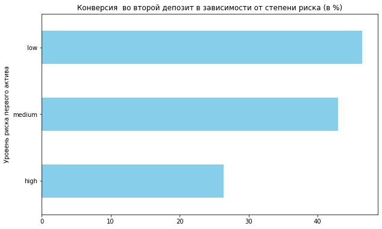

```python
# Визуализируем
df_risk = df_risk.sort_values(by='CR', ascending = True)
df_risk = df_risk.set_index('risk_level')

plt.figure(figsize=(10, 6))

df_risk['CR'].plot(kind='barh', color='skyblue')
plt.title('Конверсия  во второй депозит в зависимости от степени риска (в %)')
plt.ylabel('Уровень риска первого актива')
plt.show()
```

**Вывод:** Как и ожидалось, чем меньше риск первого депозита, тем выше конверсия во второй депозит. Это может быть связано с тем, что пользователи, выбирающие менее рискованные активы, чувствуют себя увереннее и с большей вероятностью продолжают инвестировать. А может быть, более рискованные активы требуют большей осознанности - без необходимости повторных покупок.

#### Анализ ключевой метрики на исторических данных

**Задача** Анализ ключевой метрики на исторических данных.

- На исторических данных рассчитаем значение ключевой метрики — средней суммы всех депозитов на одного пользователя. Учитываем всех пользователей, которые взаимодействовали с сервисом. Это позволит зафиксировать базовый уровень монетизации.

Формула ключевой метрики: ARPU = Общий доход (от депозитов) / Количество пользователей, взаимодействоваших с сервисом.

```python
# Группируем по пользователю и вычисляем сумму всех депозитов на пользователя
df = df_hist.groupby('user_id').agg({'amount': 'sum'}).reset_index()
```

```python
display(df.head())
```

|  | user_id | amount |
| --- | --- | --- |
| 0 | 000194d5-0b25-4c52-834d-7c812daded6a | 72.0 |
| 1 | 000230df-cb80-4a99-9eb4-6e7b559cbd0a | 103.0 |
| 2 | 00031d01-a2cc-4e28-be64-84c652318cf9 | 316.0 |
| 3 | 00039a87-007c-4aea-aa7a-f0307022ae6c | 123.0 |
| 4 | 00044258-420d-40a2-8cfe-039c6c9deffd | 128.0 |

```python
display(df['amount'].describe())
```

```
count    41032.000000
mean        91.562220
std         80.393251
min          0.000000
25%          0.000000
50%         96.000000
75%        133.000000
max        656.000000
Name: amount, dtype: float64
```

```python
display(f'Cредняя сумма всех депозитов на одного пользователя, который взаимодействовал с сервисом: \
    {df["amount"].mean().round(2)}')
```

```
'Cредняя сумма всех депозитов на одного пользователя, который взаимодействовал с сервисом:     91.56'
```

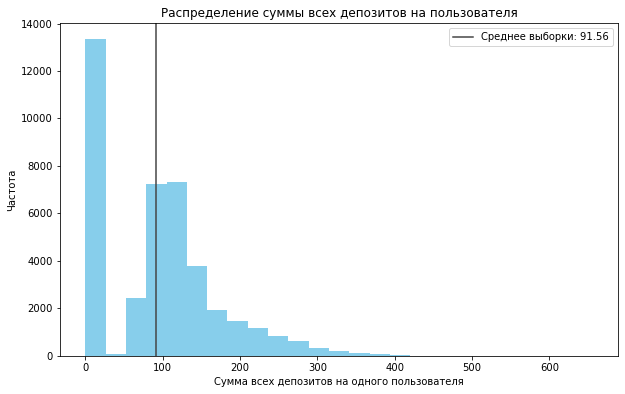

```python
# Визуализируем гистограмму - распределение суммы всех депозитов на пользователя
fig, ax = plt.subplots(figsize=(10, 6))

ax.hist(df['amount'], bins=25, color='skyblue')

ax.axvline(np.mean(df['amount']), color='#444444', linestyle='solid',
            label=f'Среднее выборки: {np.mean(df["amount"]):.2f}')

ax.set_xlabel('Сумма всех депозитов на одного пользователя')
ax.set_ylabel('Частота')
ax.set_title('Распределение суммы всех депозитов на пользователя')
ax.legend()
plt.show()
```

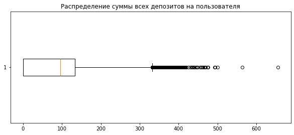

```python
# Визуализируем диаграмму размаха
plt.figure(figsize=(10, 4))

plt.boxplot(df['amount'], vert=False)
plt.title('Распределение суммы всех депозитов на пользователя')
plt.show()
```

**Вывод:** Cредняя сумма всех депозитов на одного пользователя по историческим данным - 91,56. По гистограмме распределения и диаграмме размаха видно, что форма распределения несимметричная, скошена вправо. Много пользователей не инвестирует ничего, и есть выбросы с высокими суммами. Высокое стандартное отклонение (80,4) говорит о разбросе в данных.

## Часть 2 А/В эксперимент

### Исследование результатов А/В эксперимента

Загрузим данные с результатами эксперимента (датасет `/datasets/pa_sollmafin_abt.csv`). Проверим корректность данных и проведем предобработку. Зафиксируем основную информацию о данных и предобработке в промежуточном выводе. Затем проведем анализ результатов А/В-эксперимента.

#### Загрузка данных эксперимента и их предобработка

```python
try:
    df_exp = pd.read_csv('datasets/pa_sollmafin_abt.csv', \
                         parse_dates=['first_ts', 'first_dt', 'event_ts'])
    display(f'Файл успешно загружен  в датафрейм df_exp')
except:
    display(f'Ошибка при загрузке файла')
```

```
'Файл успешно загружен  в датафрейм df_exp'
```

Смотрим структуру данных и сами данные.

```python
display(df_exp.info())
```

```
<class 'pandas.core.frame.DataFrame'>
RangeIndex: 54805 entries, 0 to 54804
Data columns (total 12 columns):
 #   Column        Non-Null Count  Dtype
---  ------        --------------  -----
 0   user_id       54805 non-null  object
 1   country_code  54805 non-null  object
 2   platform      54805 non-null  object
 3   first_ts      54805 non-null  datetime64[ns]
 4   first_dt      54805 non-null  datetime64[ns]
 5   event_ts      54805 non-null  datetime64[ns]
 6   event_name    54805 non-null  object
 7   ab_test       54805 non-null  object
 8   group         54805 non-null  object
 9   amount        7843 non-null   float64
 10  asset         3750 non-null   object
 11  risk_level    3750 non-null   object
dtypes: datetime64[ns](3), float64(1), object(8)
memory usage: 5.0+ MB
```

```
None
```

```python
display(df_exp.head())
```

|  | user_id | country_code | platform | first_ts | first_dt | event_ts | event_name | ab_test | group | amount | asset | risk_level |
| --- | --- | --- | --- | --- | --- | --- | --- | --- | --- | --- | --- | --- |
| 0 | c430acb5-c6bf-43cf-8e2d-7ab9ce0d2c8a | BR | mobile | 2025-06-07 19:55:51 | 2025-06-07 | 2025-06-07 19:55:51 | install / open_web | onboarding_test | test | NaN | NaN | NaN |
| 1 | c430acb5-c6bf-43cf-8e2d-7ab9ce0d2c8a | BR | mobile | 2025-06-07 19:55:51 | 2025-06-07 | 2025-06-07 19:55:54 | introduction | onboarding_test | test | NaN | NaN | NaN |
| 2 | c430acb5-c6bf-43cf-8e2d-7ab9ce0d2c8a | BR | mobile | 2025-06-07 19:55:51 | 2025-06-07 | 2025-06-08 06:18:09 | registration | onboarding_test | test | NaN | NaN | NaN |
| 3 | c430acb5-c6bf-43cf-8e2d-7ab9ce0d2c8a | BR | mobile | 2025-06-07 19:55:51 | 2025-06-07 | 2025-06-08 06:18:13 | main_page | onboarding_test | test | NaN | NaN | NaN |
| 4 | c430acb5-c6bf-43cf-8e2d-7ab9ce0d2c8a | BR | mobile | 2025-06-07 19:55:51 | 2025-06-07 | 2025-06-08 06:33:40 | onboarding_complete | onboarding_test | test | NaN | NaN | NaN |

```python
#Проверим на наличие явных дубликатов в данных по всем столбцам
display(f'Явных дубликатов по всем столбцам: {df_exp.duplicated().sum()}.\
        Это {df_exp.duplicated().sum()/df_exp.shape[0]} %')
```

```
'Явных дубликатов по всем столбцам: 0.        Это 0.0 %'
```

```python
# Проверим на дубликаты пользователь + дата события + событие
display(f'Дублирующихся событий пользователь + дата события + событие: {df_exp.duplicated(subset=["user_id","event_ts","event_name"]).sum()}')
```

```
'Дублирующихся событий пользователь + дата события + событие: 0'
```

Проверим интервал дат в данных.

```python
display(f'Интервал дат "first_ts": "{df_exp["first_ts"].dt.date.min()} - {df_exp["first_ts"].dt.date.max()}')
```

```
'Интервал дат "first_ts": "2025-06-02 - 2025-06-15'
```

```python
display(f'Интервал дат "first_dt": "{df_exp["first_dt"].dt.date.min()} - {df_exp["first_dt"].dt.date.max()}')
```

```
'Интервал дат "first_dt": "2025-06-02 - 2025-06-15'
```

```python
display(f'Интервал дат "event_ts": "{df_exp["event_ts"].dt.date.min()} - {df_exp["event_ts"].dt.date.max()}')
```

```
'Интервал дат "event_ts": "2025-06-02 - 2025-06-22'
```

```python
display(f'Количество уникальных пользователей: {df_exp["user_id"].nunique()}')
```

```
'Количество уникальных пользователей: 9415'
```

```python
display(f'Уникальные страны: {df_exp["country_code"].unique()}')
```

```
"Уникальные страны: ['BR' 'MX' 'CO' 'AR']"
```

```python
display(f'Уникальные платформы: {df_exp["platform"].unique()}')
```

```
"Уникальные платформы: ['mobile' 'web']"
```

```python
display(f'Уникальные события воронки: {df_exp["event_name"].unique()}')
```

```
"Уникальные события воронки: ['install / open_web' 'introduction' 'registration' 'main_page'\n 'onboarding_complete' 'first_deposit' 'asset_purchase' 'second_deposit']"
```

```python
# Данные столбца 'amount'
display(df_exp["amount"].describe())
```

```
count    7843.000000
mean      109.620681
std        86.604702
min        25.000000
25%        62.000000
50%        97.000000
75%       130.500000
max      1050.000000
Name: amount, dtype: float64
```

```python
display(f'Уникальные типы депозитов: {df_exp["asset"].unique()}')
```

```
"Уникальные типы депозитов: [nan 'crypto' 'stock' 'option']"
```

```python
display(f'Уникальные типы рисков: {df_exp["risk_level"].unique()}')
```

```
"Уникальные типы рисков: [nan 'high' 'low' 'medium']"
```

```python
display(f'Уникальные типы тестов: {df_exp["ab_test"].unique()}')
```

```
"Уникальные типы тестов: ['onboarding_test']"
```

```python
display(f'Уникальные группы теста: {df_exp["group"].unique()}')
```

```
"Уникальные группы теста: ['test' 'control']"
```

#### Анализ аудитории эксперимента

**Задача:** Анализ аудитории эксперимента.

- Проверим корректность распределения новых пользователей по группам А/В-эксперимента.

В данных 2 группы - test и control, посмотрим есть ли пересечения групп.

```python
# Считаем количество тестовых групп на пользователя
users_A_B = df_exp.groupby('user_id')['group'].nunique().reset_index()
```

```python
display(f'Количество пользователей с несколькими тестовыми группами: {users_A_B.loc[users_A_B["group"] > 1].shape[0]}')
```

```
'Количество пользователей с несколькими тестовыми группами: 0'
```

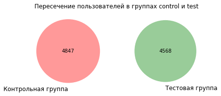

```python
# Визуализируем
# Формируем множества
set_users_control = set(df_exp['user_id'].loc[df_exp['group'] == 'control'])
set_users_test = set(df_exp['user_id'].loc[df_exp['group'] == 'test'])

# Строим диаграмму Венна
v = venn2(subsets=[set_users_control, set_users_test], \
          set_labels=('Контрольная группа', 'Тестовая группа'))
plt.title("Пересечение пользователей в группах control и test")
plt.show()
```

Проверим соотношение количества пользователей между группами.

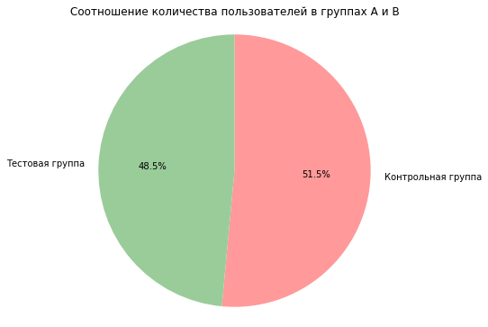

```python
# Строим круговую диаграмму
fig, ax = plt.subplots(figsize=(8, 6))
ax.pie([len(set_users_control),len(set_users_test)], labels=['Контрольная группа','Тестовая группа'], \
       autopct='%1.1f%%', startangle=90, colors=['#ff999a','#9acc99'], counterclock=False)
plt.axis('equal')
ax.set_title('Соотношение количества пользователей в группах А и В')
plt.show()
```

Посмотрим на состав участников теста по регионам.

```python
report = df_exp.groupby('country_code').agg({'user_id': 'nunique'}).rename(columns = {'user_id': 'Участники'})
report['% участников'] = (report['Участники'] / report['Участники'].sum()).round(2)
report.sort_values(by = 'Участники', ascending = False)
```

| country_code | Участники | % участников |
| --- | --- | --- |
| BR | 2991 | 0.32 |
| MX | 2497 | 0.27 |
| CO | 2446 | 0.26 |
| AR | 1481 | 0.16 |

В Аргентине - процент участников эксперимента меньше, чем в других странах. Сравним распределение по странам между тестовыми группами.

```python
report = df_exp.groupby(['group', 'country_code']).agg({'user_id': 'nunique'}).rename(columns = {'user_id': 'Участники'}).reset_index()
```

```python
# перевернем таблицу для удобства визуализации
report = report.pivot_table(index='country_code', columns='group', values='Участники').reset_index()
```

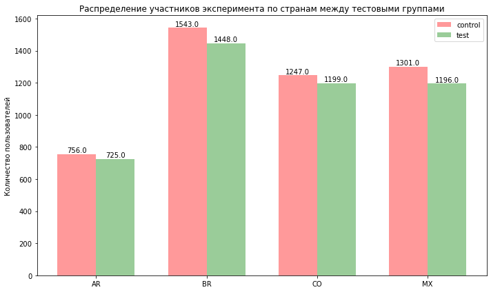

```python
# Визуализируем
# Данные для диаграммы
категории = report['country_code']
значения1 = report['control']
значения2 = report['test']
# Ширина столбцов
ширина_столбца = 0.35

# Создание списка позиций для столбцов на оси X
позиции = np.arange(len(report))

# Создание объектов фигуры и осей
fig, ax = plt.subplots(figsize=(10, 6))

# Построение столбчатых диаграмм
прямоугольник1 = ax.bar(позиции - ширина_столбца/2, значения1, ширина_столбца, label='control', color='#ff999a')
прямоугольник2 = ax.bar(позиции + ширина_столбца/2, значения2, ширина_столбца, label='test', color='#9acc99')

# Настройка оси X
ax.set_xticks(позиции)
ax.set_xticklabels(категории)
ax.set_ylabel('Количество пользователей')
ax.set_title('Распределение участников эксперимента по странам между тестовыми группами')
ax.legend()

# Добавление подписей над столбцами
def add_labels(rects, ax):
    for rect in rects:
        height = rect.get_height()
        ax.text(rect.get_x() + rect.get_width()/2., height + 2,
                f'{height}',
                ha='center', va='bottom')

add_labels(прямоугольник1, ax)
add_labels(прямоугольник2, ax)

# Отображение диаграммы
plt.tight_layout()
plt.show()
```

Количество участников эксперимента по странам между тестовой и контрольной группами - сопоставимо.

Посмотрим на состав участников теста по платформам.

```python
report = df_exp.groupby('platform').agg({'user_id': 'nunique'}).rename(columns = {'user_id': 'Участники'})
report['% участников'] = (report['Участники'] / report['Участники'].sum()).round(2)
report.sort_values(by = 'Участники', ascending = False)
```

| platform | Участники | % участников |
| --- | --- | --- |
| mobile | 6631 | 0.7 |
| web | 2784 | 0.3 |

Количество пользователей с десктопной версией - меньше. Также сравним количество между группами.

```python
report = df_exp.groupby(['group', 'platform']).agg({'user_id': 'nunique'}).rename(columns = {'user_id': 'Участники'}).reset_index()
report = report.pivot_table(index='platform', columns='group', values='Участники').reset_index()
```

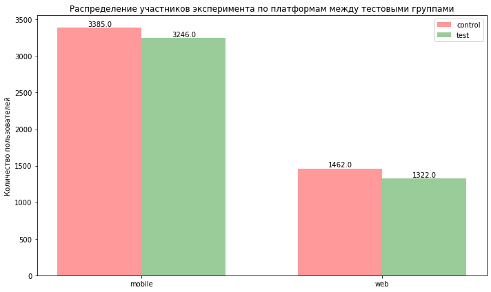

```python
# Визуализируем
# Данные для диаграммы
категории = report['platform']
значения1 = report['control']
значения2 = report['test']
# Ширина столбцов
ширина_столбца = 0.35

# Создание списка позиций для столбцов на оси X
позиции = np.arange(len(report))

# Создание объектов фигуры и осей
fig, ax = plt.subplots(figsize=(10, 6))

# Построение столбчатых диаграмм
прямоугольник1 = ax.bar(позиции - ширина_столбца/2, значения1, ширина_столбца, label='control', color='#ff999a')
прямоугольник2 = ax.bar(позиции + ширина_столбца/2, значения2, ширина_столбца, label='test', color='#9acc99')

# Настройка оси X
ax.set_xticks(позиции)
ax.set_xticklabels(категории)
ax.set_ylabel('Количество пользователей')
ax.set_title('Распределение участников эксперимента по платформам между тестовыми группами')
ax.legend()

# Добавление подписей над столбцами
def add_labels(rects, ax):
    for rect in rects:
        height = rect.get_height()
        ax.text(rect.get_x() + rect.get_width()/2., height + 2,
                f'{height}',
                ha='center', va='bottom')

add_labels(прямоугольник1, ax)
add_labels(прямоугольник2, ax)

# Отображение диаграммы
plt.tight_layout()
plt.show()
```

Количество участников эксперимента по платформам между тестовой и контрольной группами - сопоставимо.

**Вывод:** В А/В тесте участвует 9415 пользователей. Пересечений между группами не наблюдается. В контрольной группе 4847 человек (51,5%), в тестовой - 4568 (48,5%). Расхождение между группами в 3% - допускается. Распределение участников по странам и платформам между тестовыми группами - равномерное.

#### Классическая и пошаговая воронки: сравнение двух групп

**Задача:** Сравнение воронок событий.

- Сравним пользовательский путь новых пользователей в тестовой и контрольной группах.
- Построим классическую и последовательную воронки, выполним визуализацию и сделаем промежуточный вывод.

```python
# Задаем порядок шагов в воронке
funnel_steps = ['install / open_web','introduction','registration','main_page','onboarding_complete',\
                'first_deposit','asset_purchase','second_deposit']
```

```python
# Разделим данные по тестовым группам
control_df = df_exp.loc[df_exp['group'] == 'control']
test_df = df_exp.loc[df_exp['group'] == 'test']
```

Считаем показатели воронок для контрольной группы

```python
# Для контрольной группы - считаем количество клиентов на каждом шаге
counts_control_agg = control_df.groupby('event_name')['user_id'].nunique().reindex(funnel_steps)
```

```python
# Классическая воронка: для контрольной группы - cчитаем конверсию от первого шага
control_classic_funnel = ((counts_control_agg.values / counts_control_agg.values[0]) * 100).round(1)
```

```python
# Пошаговая воронка: для контрольной группы - cчитаем конверсию от предыдущего шага
control_step_funnel = (counts_control_agg.values / counts_control_agg.shift(1) * 100).round(1)
```

Считаем показатели воронок для тестовой группы

```python
# Для тестовой группы - считаем количество клиентов на каждом шаге
counts_test_agg = test_df.groupby('event_name')['user_id'].nunique().reindex(funnel_steps)
```

```python
# Классическая воронка: для тестовой группы - cчитаем конверсию от первого шага
test_classic_funnel = ((counts_test_agg.values / counts_test_agg.values[0]) * 100).round(1)
```

```python
# Пошаговая воронка: для тестовой группы - cчитаем конверсию от предыдущего шага
test_step_funnel = (counts_test_agg.values / counts_test_agg.shift(1) * 100).round(1)
```

```python
# Соберём данные в датафрейм
funnel_compare = pd.DataFrame({
   'control_classic': control_classic_funnel,
   'control_step': control_step_funnel,
   'test_classic': test_classic_funnel,
   'test_step': test_step_funnel})
```

```python
display(funnel_compare.head(8))
```

| event_name | control_classic | control_step | test_classic | test_step |
| --- | --- | --- | --- | --- |
| install / open_web | 100.0 | NaN | 100.0 | NaN |
| introduction | 100.0 | 100.0 | 100.0 | 100.0 |
| registration | 93.1 | 93.1 | 93.4 | 93.4 |
| main_page | 85.8 | 92.2 | 85.8 | 91.9 |
| onboarding_complete | 83.8 | 97.6 | 75.8 | 88.3 |
| first_deposit | 66.6 | 79.4 | 65.4 | 86.3 |
| asset_purchase | 36.6 | 54.9 | 43.3 | 66.2 |
| second_deposit | 13.5 | 36.9 | 21.3 | 49.3 |

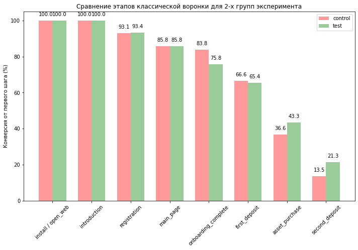

```python
# Визуализируем классическую воронку в сравнении по тестовым группам
# Данные для диаграммы
категории = funnel_compare.index
значения1 = funnel_compare['control_classic']
значения2 = funnel_compare['test_classic']

# Ширина столбцов
ширина_столбца = 0.35

# Создание списка позиций для столбцов на оси X
позиции = np.arange(len(funnel_compare))

# Создание объектов фигуры и осей
fig, ax = plt.subplots(figsize=(10, 6))

# Построение столбчатых диаграмм
прямоугольник1 = ax.bar(позиции - ширина_столбца/2, значения1, ширина_столбца, label='control', color='#ff999a')
прямоугольник2 = ax.bar(позиции + ширина_столбца/2, значения2, ширина_столбца, label='test', color='#9acc99')

# Настройка оси X
ax.set_xticks(позиции)
ax.set_xticklabels(категории)
ax.set_ylabel('Конверсия от первого шага (%)')
ax.set_title('Сравнение этапов классической воронки для 2-х групп эксперимента')
ax.legend()

# Добавление подписей над столбцами
def add_labels(rects, ax):
    for rect in rects:
        height = rect.get_height()
        ax.text(rect.get_x() + rect.get_width()/2., height + 2,
                f'{height}',
                ha='center', va='bottom')

add_labels(прямоугольник1, ax)
add_labels(прямоугольник2, ax)

# Отображение диаграммы
plt.tight_layout()
plt.xticks(rotation=45)
plt.show()
```

**Вывод:** По классической воронке в тестовой группе значительно выросло количество пользователей на последнем шаге воронки - 2 депозит - 21,3% против 13,5% в контрольной (разница 7,8%). Также в тестовой группе на 6,7% выросло количество на шаге "покупка актива" (тестовая - 43,3%, контрольная - 36,6%).

Но на 8% в тестовой группе упало количество пользователей при переходе к шагу "завершение онбординга". И на 1,2% в тестовой группе снизилось количество инвестирующих в 1 депозит. Это связано с изменениями в новом интерфейсе онбординга.

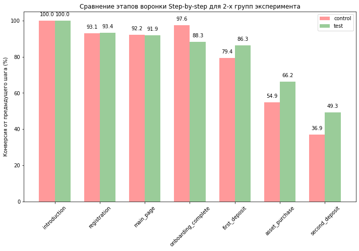

```python
# Визуализируем пошаговую воронку в сравнении по тестовым группам - не берем первый шаг, т.к. не с чем сравнивать
# Данные для диаграммы
категории = funnel_compare.index[1:]
значения1 = funnel_compare['control_step'].iloc[1:]
значения2 = funnel_compare['test_step'].iloc[1:]

# Ширина столбцов
ширина_столбца = 0.35

# Создание списка позиций для столбцов на оси X
позиции = np.arange(len(funnel_compare)-1)

# Создание объектов фигуры и осей
fig, ax = plt.subplots(figsize=(10, 6))

# Построение столбчатых диаграмм
прямоугольник1 = ax.bar(позиции - ширина_столбца/2, значения1, ширина_столбца, label='control', color='#ff999a')
прямоугольник2 = ax.bar(позиции + ширина_столбца/2, значения2, ширина_столбца, label='test', color='#9acc99')

# Настройка оси X
ax.set_xticks(позиции)
ax.set_xticklabels(категории)
ax.set_ylabel('Конверсия от предыдущего шага (%)')
ax.set_title('Сравнение этапов воронки Step-by-step для 2-х групп эксперимента')
ax.legend()

# Добавление подписей над столбцами
def add_labels(rects, ax):
    for rect in rects:
        height = rect.get_height()
        ax.text(rect.get_x() + rect.get_width()/2., height + 2,
                f'{height}',
                ha='center', va='bottom')

add_labels(прямоугольник1, ax)
add_labels(прямоугольник2, ax)

# Отображение диаграммы
plt.tight_layout()
plt.xticks(rotation=45)
plt.show()
```

**Вывод:** По пошаговой воронке в тестовой группе также выросло количество пользователей на последнем шаге воронки - 2 депозит - 49,3% против 36,9% в контрольной (разница 12,4%). Также в тестовой группе на 11,3% выросло количество пользователей на шаге "покупка актива" (тестовая - 66,2%, контрольная - 54,9%).

Также, как в классической, на 9,3% в тестовой группе упало количество пользователей при переходе к шагу "завершение онбординга". Но, в отличе от классической, для тестовой величилось количество инвесторов в 1 депозит на 6,9%.

Т.е., те пользователи, которые досмотрели углубленный онбординг в новом интерфейсе, стали чаще инвестировать в 1 депозит, покупать активы и доходить до последнего шага воронки - 2-го депозита.

#### Влияние новой фичи на конверсию во второй депозит с учётом уровня риска купленного актива.

**Задача:** Оценим влияние новой фичи на конверсию во второй депозит с учётом уровня риска купленного актива.

- Проанализируем, как категория риска купленного актива влияет на вероятность открытия второго депозита в тестовой и контрольной группах.
- Сравним результаты и оценим, есть ли статистически значимая разница между группами.

Столбец 'уровень риска' 'risk_level' заполняется только для события 'asset_purchase', после совершения события 'first_deposit'. Поэтому сформируем цепочку событий для пользователя - 'asset_purchase'- 'second_deposit'.

```python
# Выбираем пользователей, которые совершили покупку актива после 1 депозита
df_users_asset = df_exp.loc[df_exp['event_name'] == 'asset_purchase']
```

```python
# Выбираем пользователей, которые открыли 2 депозит
df_users_2_deposit = df_exp.loc[df_exp['event_name'] == 'second_deposit']
```

```python
# Объединим данные по пользователю
df_user_risk = pd.merge(df_users_asset[['user_id','group','event_name','risk_level']],
              df_users_2_deposit[['user_id', 'event_name','amount']], on='user_id', how='left' )
```

```python
# Сгурппируем по степени риска и группе эксперимента и посчитаем количество уникальных пользователей с 1 депозитом
df_risk_1 = df_user_risk.groupby(['group','risk_level'])['user_id'].nunique().reset_index()
```

```python
# Переименуем столбец
df_risk_1 = df_risk_1.rename(columns = {'user_id': 'count_dep1'})
```

```python
# Выберем пользователей с событием "второй депозит",
# сгруппируем по степени риска и тестовой группе и посчитаем уникальное количество пользователей
df_risk_2 = df_user_risk.loc[df_user_risk['event_name_y'] == 'second_deposit'].groupby(['group','risk_level'])\
            ['user_id'].nunique().reset_index()
```

```python
# Переименуем столбец
df_risk_2 = df_risk_2.rename(columns = {'user_id': 'count_dep2'})
```

```python
# Объединим посчитанные данные
df_risk = pd.merge(df_risk_1, df_risk_2, on=['group','risk_level'], how='left')
```

```python
# Рассчитаем показатель конверсии
df_risk['CR'] = round((df_risk['count_dep2']/df_risk['count_dep1']) * 100,2)
```

```python
# перевернем таблицу для удобства визуализации
report = df_risk.pivot_table(index='risk_level', columns='group', values='CR')
```

```python
report = report.sort_values(by='test', ascending = True)
```

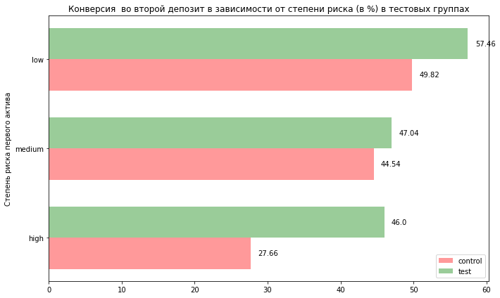

```python
# Визуализируем
# Данные для диаграммы
категории = report.index
значения1 = report['control']
значения2 = report['test']

# Ширина столбцов
ширина_столбца = 0.35

# Создание списка позиций для столбцов на оси X
позиции = np.arange(len(report))

# Создание объектов фигуры и осей
fig, ax = plt.subplots(figsize=(10, 6))

# Построение столбчатых диаграмм
barh1 = ax.barh(позиции - ширина_столбца/2, значения1, ширина_столбца, label='control', color='#ff999a')
barh2 = ax.barh(позиции + ширина_столбца/2, значения2, ширина_столбца, label='test', color='#9acc99')

# Добавление числовых меток для каждого столбца
for bar in barh1:
    width = bar.get_width()  # Получаем ширину столбца
    # Добавляем текст (значение) рядом с столбцом
    ax.text(width + 1,  # Координата X (небольшое смещение от конца столбца)
            bar.get_y() + bar.get_height()/2,  # Координата Y (центр столбца)
            f'{width}',  # Текст метки (значение столбца)
            va='center') # Выравнивание по центру по вертикали

for bar in barh2:
    width = bar.get_width()  # Получаем ширину столбца
    # Добавляем текст (значение) рядом с столбцом
    ax.text(width + 1,  # Координата X (небольшое смещение от конца столбца)
            bar.get_y() + bar.get_height()/2,  # Координата Y (центр столбца)
            f'{width}',  # Текст метки (значение столбца)
            va='center') # Выравнивание по центру по вертикали


# Настройка оси X
ax.set_yticks(позиции)
ax.set_yticklabels(категории)
ax.set_ylabel('Степень риска первого актива')
ax.set_title('Конверсия  во второй депозит в зависимости от степени риска (в %) в тестовых группах')
ax.legend()

# Отображение диаграммы
plt.tight_layout()
plt.show()
```

Проверим статистическую значимость полученных данных с помощью Z-теста, т.к. оцениваются доли.

Формулируем гипотезы:

- H0: Доля пользователей, инвестирующих во второй депозит в контрольной и тестовой группах не различается.
- H1: Доля пользователей, инвестирующих во второй депозит в тестовой группе больше, чем в контрольной (правосторонняя гипотеза).

```python
# Считаем размеры групп
n_a = df_exp.loc[df_exp['group'] == 'control']['user_id'].nunique()
n_b = df_exp.loc[df_exp['group'] == 'test']['user_id'].nunique()
```

```python
# Считаем количество успехов в группах
m_a = df_exp.loc[(df_exp['group'] == 'control') & (df_exp['event_name'] == 'second_deposit')]['user_id'].nunique()
m_b = df_exp.loc[(df_exp['group'] == 'test') & (df_exp['event_name'] == 'second_deposit')]['user_id'].nunique()
```

```python
# Считаем долю успехов для каждой группы
p_a, p_b = m_a/n_a, m_b/n_b

# Проверяем предпосылку о достаточном количестве данных
if (p_a*n_a > 10) and ((1-p_a)*n_a > 10) and (p_b*n_b > 10) and ((1-p_b)*n_b > 10):
    display('Предпосылка о достаточном количестве данных выполняется!')
else:
    display('Предпосылка о достаточном количестве данных НЕ выполняется!')
```

```
'Предпосылка о достаточном количестве данных выполняется!'
```

```python
# Применяем Z-тест пропорций
alpha = 0.05 ## уровень значимости

# smaller - pa<pb
stat_ztest, p_value_ztest = proportions_ztest([m_a, m_b],[n_a, n_b],alternative='smaller')

display(f'pvalue = {p_value_ztest}')

if p_value_ztest < alpha:
    display('Отвергаем H0. Принимаем альтернативную гипотезу: Доля пользователей, \
инвестирующих во второй депозит в тестовой группе больше, чем в контрольной.')
else:
    display('Подтверждаем H0. Доля пользователей, инвестирующих во второй депозит \
в контрольной и тестовой группах не различается.')
```

```
'pvalue = 5.095691512806142e-24'
```

```
'Отвергаем H0. Принимаем альтернативную гипотезу: Доля пользователей, инвестирующих во второй депозит в тестовой группе больше, чем в контрольной.'
```

#### Анализ метрик А/В-эксперимента

**Задача:** Анализ метрик А/В-эксперимента. Проанализируем такие метрики:

- Ключевая метрика — средняя сумма всех депозитов на одного пользователя (включая тех, кто установил приложение или открыл веб-версию).
- Барьерная метрика — конверсия из регистрации в первый депозит.
- Вспомогательная метрика 1 — конверсия из первого депозита во второй.
- Вспомогательная метрика 2 — средняя сумма всех депозитов на пользователя, который открыл хотя бы один депозит.

Для каждой метрики выведем:

- значения в контрольной и тестовой группах,
- абсолютные и относительные изменения значений в тестовой группе по сравнению с контрольной.

Проверим статистическую значимость различий метрик между группами эксперимента.

Для ключевой метрики также изучим:

- накопленную динамику изменения по дням эксперимента для каждой группы,
- стабильность p-value во время эксперимента.

##### Ключевая метрика

Ключевая метрика — средняя сумма всех депозитов на одного пользователя (включая тех, кто установил приложение или открыл веб-версию): ARPU = Общий доход (от депозитов) / Количество пользователей, взаимодействоваших с сервисом.

Визуализируем данные для ключевой метрики.

```python
# Выбираем пользователей группы и считаем для каждого сумму депозитов
df_plot_control = df_exp.loc[df_exp['group'] == 'control']
df_plot_control = df_plot_control.groupby('user_id')['amount'].sum()
df_plot_test = df_exp.loc[df_exp['group'] == 'test']
df_plot_test = df_plot_test.groupby('user_id')['amount'].sum()
```

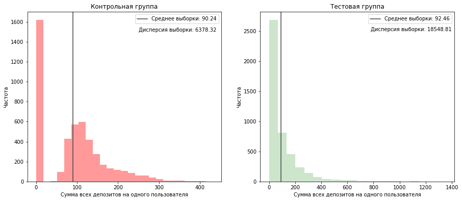

```python
# Визуализируем гистограмму - распределение суммы всех депозитов на пользователя
plt.figure(figsize=(15, 6))

ax = plt.subplot(1, 2, 1)
ax.hist(df_plot_control, bins=25, color='#ff999a' )
ax.axvline(np.mean(df_plot_control), color='#444444', linestyle='solid',\
            label=f'Среднее выборки: {np.mean(df_plot_control):.2f}')
ax.text(250, 1500, f'Дисперсия выборки: {round(np.var(df_plot_control),2)}')
ax.set_title('Контрольная группа')
ax.set_xlabel('Сумма всех депозитов на одного пользователя')
ax.set_ylabel('Частота')
ax.legend()


ax= plt.subplot(1, 2 , 2)
ax.hist(df_plot_test, bins=20, alpha=0.5, color='#9acc99')
ax.set_title('Тестовая группа')
ax.axvline(np.mean(df_plot_test), color='#444444', linestyle='solid',\
            label=f'Среднее выборки: {np.mean(df_plot_test):.2f}')
ax.text(780, 2500, f'Дисперсия выборки: {round(np.var(df_plot_test),2)}')
ax.set_xlabel('Сумма всех депозитов на одного пользователя')
ax.set_ylabel('Частота')
ax.legend()
plt.show()
```

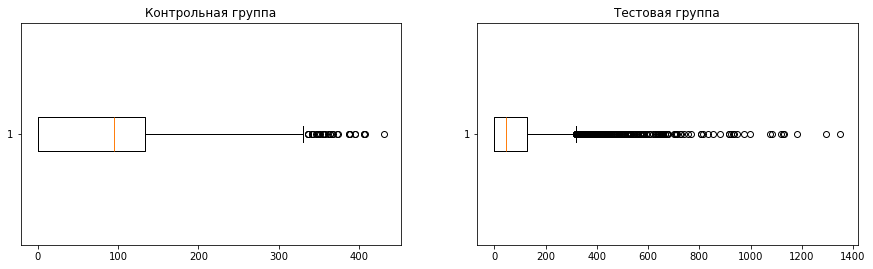

```python
# Визуализируем диаграмму размаха

plt.figure(figsize=(15, 4))

ax = plt.subplot(1, 2, 1)
ax.boxplot(df_plot_control, vert=False)
ax.set_title('Контрольная группа')

ax= plt.subplot(1, 2 , 2)
ax.boxplot(df_plot_test, vert=False)
ax.set_title('Тестовая группа')
plt.show()
```

**Вывод:** распределения сумм скошены вправо, присутствую выбросы, выборочные дисперсии не равны. Для проверки статистической значимости будем использовать тест Уэлча

```python
# Группируем по пользователю и тестовой группе и вычисляем сумму всех депозитов на пользователя
df_exp_users = df_exp.groupby(['group','user_id']).agg({'amount': 'sum'}).reset_index()
```

```python
# Группируем по тестовой группе и считаем метрику
df_exp_users_agg = df_exp_users.groupby('group')['amount'].mean().reset_index()
```

```python
result = df_exp_users_agg.pivot_table(columns='group',values='amount')
result['Absolute Lift'] = round(result['test'] - result['control'],2)
result['Relative Lift (%)'] =  round(100*(result['test']/result['control']-1),2)
```

```python
display(result[:5])
```

| group | control | test | Absolute Lift | Relative Lift (%) |
| --- | --- | --- | --- | --- |
| amount | 90.240149 | 92.460814 | 2.22 | 2.46 |

**Вывод:** Ключевая метрика - средняя сумма всех депозитов на одного пользователя - в тестовой группе выросла на 2,46%.

**Накопленная динамика ключевой метрики**

Рассчитаем и визуализируем кумулятивное значение ключевой метрики для тестовых групп за весь период эксперимента. Для этого сформируем датасет:

- group (группа эксперимента),
- data (дата эксперимента)
- значение ключевой метрики до даты эксперимента

```python
# Формируем список дат для цикла и сортируем его
date_list = df_exp['event_ts'].dt.date.unique()
date_list.sort()
```

```python
records = []
for current_date in date_list:
    # Выбираем все события до текущей даты включительно
    df_exp_to_date = df_exp.loc[df_exp['event_ts'].dt.date <= current_date]

    # Группируем по пользователю и тестовой группе и вычисляем сумму всех депозитов на пользователя
    df_ = df_exp_to_date.groupby(['group','user_id']).agg(apru = ('amount','sum')).reset_index()
    # Группируем по тестовой группе и считаем метрику
    df_ = df_.groupby('group')['apru'].mean().reset_index()
    df_['date'] = current_date
    records.append(df_)

    # Собираем всё в итоговый датафрейм
    report = pd.concat(records)
```

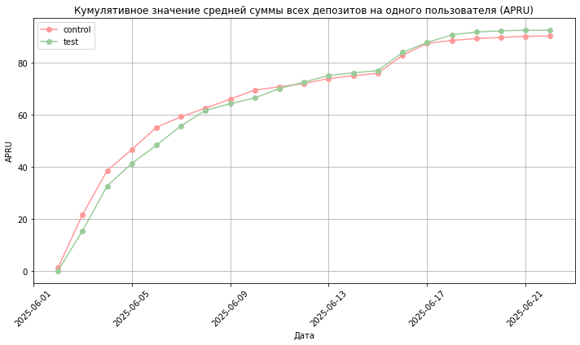

```python
# Строим график
color_list = ['#ff999a','#9acc99']
plt.figure(figsize=(10, 6))
for group, color_ in zip(report['group'].unique(), range(0, len(color_list))):
    group_data = report.loc[report['group'] == group]
    plt.plot(group_data['date'], group_data['apru'] , color=color_list[color_], marker='o', label=group)

plt.title('Кумулятивное значение средней суммы всех депозитов на одного пользователя (APRU)')
plt.xlabel('Дата')
plt.ylabel('APRU')
plt.grid(True)
plt.legend()
plt.xticks(rotation=45)
plt.tight_layout()
plt.show()
```

**Вывод:** По графику видно, как происходило накопление коллективного пользовательского опыта в тестовой группе - до 12 июня ключевая метрика в контрольной группе была выше, чем тестовой. Но, после 12 июня, метрика в тестовой группе стала выше и оставалась выше до конца эксперимента. Также стоит обратить снимание на "ступеньки" - то, что они появились, может намекать нам на то, что пользователи начали делать вторые, крупные депозиты. А ступенька после 16 числа - именно в этот день завершился набор новых пользователей, и далее в выборке остались только активные пользователи.

Посмотрим на динамику p-value по дням эксперимента.

```python
pval_records = []

for current_date in date_list:
    # Выбираем все события до текущей даты включительно
    df_exp_to_date = df_exp.loc[df_exp['event_ts'].dt.date <= current_date]

    group_control = df_exp_to_date.loc[df_exp_to_date['group'] =='control'].groupby('user_id')['amount'].mean().reset_index()
    group_test = df_exp_to_date.loc[df_exp_to_date['group'] =='test'].groupby('user_id')['amount'].mean().reset_index()

    # Заменим Nan для тех пользователей, котороые не совершали депозитов, на 0
    group_control['amount'] = group_control['amount'].fillna(0)
    group_test['amount'] = group_test['amount'].fillna(0)

    # Тестируем
    result = st.ttest_ind(group_control['amount'], group_test['amount'], equal_var=False, alternative = 'greater')

    pval_records.append({'date': current_date,'p_value': result.pvalue})

# Собираем всё в итоговый датафрейм
df_pvalue = pd.DataFrame(pval_records)
```

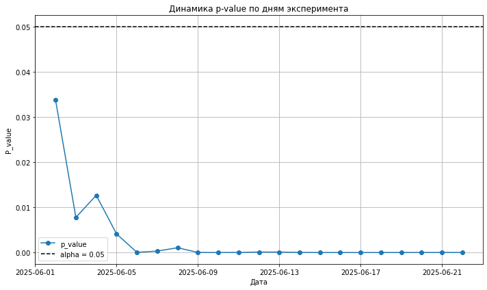

```python
# Строим график
plt.figure(figsize=(10, 6))
plt.plot(df_pvalue['date'], df_pvalue['p_value'], marker='o', label='p_value' )

plt.title('Динамика p-value по дням эксперимента')
plt.xlabel('Дата')
plt.ylabel('P_value')
plt.grid(True)

plt.axhline(y=0.05, linestyle='--', color='black', label='alpha = 0.05')
plt.legend()
plt.tight_layout()
plt.show()
```

**Вывод:** Динамика p_value по дням отражает (несмотря на колебания в начале) устойчивое значение ниже уровня значимости с первых дней до конца эксперимента, что говорит о стабильном результате.

**Барьерная метрика**

Барьерная метрика — конверсия из регистрации в первый депозит.

```python
#Отбираем пользователей с собитием "регистрация"
df_registration = df_exp.loc[df_exp['event_name'] == 'registration']
```

```python
# Группируем по тестовой группе и считаем количество уникальных пользователей
df_registration = df_registration.groupby('group')['user_id'].nunique().reset_index()
```

```python
# Переименуем столбец
df_registration = df_registration.rename(columns = {'user_id': 'registration_users'})
```

```python
#Отбираем пользователей с событием "1 депозит"
df_1_deposit = df_exp.loc[df_exp['event_name'] == 'first_deposit']
```

```python
# Группируем по тестовой группе и считаем количество уникальных пользователей
df_1_deposit = df_1_deposit.groupby('group')['user_id'].nunique().reset_index()
```

```python
# Переименуем столбец
df_1_deposit = df_1_deposit.rename(columns = {'user_id': 'deposit_1_users'})
```

```python
# Объединяем данные
result = pd.merge(df_registration, df_1_deposit, on = 'group', how='inner')
```

```python
# Рассчитываем показатели
result['CR'] = round((result['deposit_1_users']/result['registration_users'])*100,2)
```

```python
# Перевернем таблицу и продолжим рассчитывать показатели
result = result.pivot_table(columns='group')
result['Absolute Lift'] = round(result['test'] - result['control'],2)
result['Relative Lift (%)'] =  round(100*(result['test']/result['control']-1),2)
```

```python
display(result[:5])
```

| group | control | test | Absolute Lift | Relative Lift (%) |
| --- | --- | --- | --- | --- |
| CR | 71.54 | 70.04 | -1.5 | -2.10 |
| deposit_1_users | 3228.00 | 2987.00 | -241.0 | -7.47 |
| registration_users | 4512.00 | 4265.00 | -247.0 | -5.47 |

Проверим статистическую значимость полученных данных с помощью Z-теста, т.к. оцениваются доли.

Формулируем гипотезы:

- H0: Доля пользователей, инвестирующих из регистрации в 1 депозит в контрольной и тестовой группах не различается.
- H1: Доля пользователей, инвестирующих из регистрации в 1 депозит в тестовой группе больше, чем в контрольной (правосторонняя гипотеза).

```python
# Считаем размеры групп для события "регистрация"
n_a = df_exp.loc[(df_exp['group'] == 'control') & (df_exp['event_name'] == 'registration')]['user_id'].nunique()
n_b = df_exp.loc[(df_exp['group'] == 'test') & (df_exp['event_name'] == 'registration')]['user_id'].nunique()
```

```python
# Считаем количество успехов в группах
m_a = df_exp.loc[(df_exp['group'] == 'control') & (df_exp['event_name'] == 'first_deposit')]['user_id'].nunique()
m_b = df_exp.loc[(df_exp['group'] == 'test') & (df_exp['event_name'] == 'first_deposit')]['user_id'].nunique()
```

```python
# Считаем долю успехов для каждой группы
p_a, p_b = m_a/n_a, m_b/n_b

# Проверяем предпосылку о достаточном количестве данных
if (p_a*n_a > 10) and ((1-p_a)*n_a > 10) and (p_b*n_b > 10) and ((1-p_b)*n_b > 10):
    display('Предпосылка о достаточном количестве данных выполняется!')
else:
    display('Предпосылка о достаточном количестве данных НЕ выполняется!')
```

```
'Предпосылка о достаточном количестве данных выполняется!'
```

```python
# Применяем Z-тест пропорций
alpha = 0.05 ## уровень значимости

# smaller - pa<pb
stat_ztest, p_value_ztest = proportions_ztest([m_a, m_b],[n_a, n_b],alternative='smaller')

display(f'pvalue = {p_value_ztest}')

if p_value_ztest < alpha:
    display('Отвергаем H0. Принимаем альтернативную гипотезу: Конверсия из регистрации в 1 депозит \
в тестовой группе выше, чем в контрольной.')
else:
    display('Подтверждаем H0. Конверсия из регистрации в 1 депозит \
в контрольной и тестовой группах не различается.')
```

```
'pvalue = 0.9397282759544358'
```

```
'Подтверждаем H0. Конверсия из регистрации в 1 депозит в контрольной и тестовой группах не различается.'
```

**Вывод:** В расчетах по данным эксперимента барьерная метрика - конверсия из регистрации в первый депозит- в тестовой группе упала на 2,1%. Но статистический тест говорит о том, что различий между тестовыми группами по этому показателю не наблюдается. Значит, падение барьерной метрики можно считать случайностью, и не подтвердилась гипотеза риска о том, что информация о возможных потерях и высоких рисках отпугнёт новичков.

**Вспомогательные метрики**

**Вспомогательная метрика 1 — конверсия из первого депозита во второй**

```python
#Отбираем пользователей с событием "2 депозит"
df_2_deposit = df_exp.loc[df_exp['event_name'] == 'second_deposit']
```

```python
# Группируем по тестовой группе и считаем количество уникальных пользователей
df_2_deposit = df_2_deposit.groupby('group')['user_id'].nunique().reset_index()
```

```python
# Переименуем столбец
df_2_deposit = df_2_deposit.rename(columns = {'user_id': 'deposit_2_users'})
```

Используем датасет **df_1_deposit** с данными о пользователях с событием "1 депозит".

```python
# Объединяем данные
result = pd.merge(df_1_deposit, df_2_deposit, on = 'group', how='inner')
```

```python
display(result[0:5])
```

|  | group | deposit_1_users | deposit_2_users |
| --- | --- | --- | --- |
| 0 | control | 3228 | 654 |
| 1 | test | 2987 | 974 |

```python
# Рассчитываем показатели
result['CR'] = round((result['deposit_2_users']/result['deposit_1_users'])*100,2)
```

```python
# Перевернем таблицу и продолжим рассчитывать показатели
result = result.pivot_table(columns='group')
result['Absolute Lift'] = round(result['test'] - result['control'],2)
result['Relative Lift (%)'] =  round(100*(result['test']/result['control']-1),2)
```

```python
display(result.head())
```

| group | control | test | Absolute Lift | Relative Lift (%) |
| --- | --- | --- | --- | --- |
| CR | 20.26 | 32.61 | 12.35 | 60.96 |
| deposit_1_users | 3228.00 | 2987.00 | -241.00 | -7.47 |
| deposit_2_users | 654.00 | 974.00 | 320.00 | 48.93 |

Проверим статистическую значимость полученных данных с помощью Z-теста, т.к. оцениваются доли.

Формулируем гипотезы:

- H0: Доля пользователей, инвестирующих из 1 депозита во 2 депозит в контрольной и тестовой группах не различается.
- H1: Доля пользователей, инвестирующих из 1 депозита во 2 депозит в тестовой группе больше, чем в контрольной (правосторонняя гипотеза).

```python
# Считаем размеры групп для события "первый депозит"
n_a = df_exp.loc[(df_exp['group'] == 'control') & (df_exp['event_name'] == 'first_deposit')]['user_id'].nunique()
n_b = df_exp.loc[(df_exp['group'] == 'test') & (df_exp['event_name'] == 'first_deposit')]['user_id'].nunique()
```

```python
# Считаем количество успехов в группах
m_a = df_exp.loc[(df_exp['group'] == 'control') & (df_exp['event_name'] == 'second_deposit')]['user_id'].nunique()
m_b = df_exp.loc[(df_exp['group'] == 'test') & (df_exp['event_name'] == 'second_deposit')]['user_id'].nunique()
```

```python
# Считаем долю успехов для каждой группы
p_a, p_b = m_a/n_a, m_b/n_b

# Проверяем предпосылку о достаточном количестве данных
if (p_a*n_a > 10) and ((1-p_a)*n_a > 10) and (p_b*n_b > 10) and ((1-p_b)*n_b > 10):
    display('Предпосылка о достаточном количестве данных выполняется!')
else:
    display('Предпосылка о достаточном количестве данных НЕ выполняется!')
```

```
'Предпосылка о достаточном количестве данных выполняется!'
```

```python
# Применяем Z-тест пропорций
alpha = 0.05 ## уровень значимости

# smaller - pa<pb
stat_ztest, p_value_ztest = proportions_ztest([m_a, m_b],[n_a, n_b],alternative='smaller')

display(f'pvalue = {p_value_ztest}')

if p_value_ztest < alpha:
    display('Отвергаем H0. Принимаем альтернативную гипотезу: Конверсия из 1 депозита во 2 депозит \
в тестовой группе выше, чем в контрольной.')
else:
    display('Подтверждаем H0. Конверсия из 1 депозита во 2 депозит \
в контрольной и тестовой группах не различается.')
```

```
'pvalue = 9.677942837686964e-29'
```

```
'Отвергаем H0. Принимаем альтернативную гипотезу: Конверсия из 1 депозита во 2 депозит в тестовой группе выше, чем в контрольной.'
```

**Вывод:** Получили статистически значимые данные - рост вспомогательной метрики в тестовой группе — конверсия из первого депозита во второй - на 60,96%.

**Вспомогательная метрика 2 — средняя сумма всех депозитов на пользователя, который открыл хотя бы один депозит**

```python
#Отбираем пользователей с событием "1 депозит"
df_1_deposit = df_exp.loc[df_exp['event_name'] == 'first_deposit']
```

```python
# Группируем по тестовой группе и считаем количество уникальных пользователей
df_1_deposit = df_1_deposit.groupby('group')['user_id'].nunique().reset_index()
```

```python
# Переименуем столбец
df_1_deposit = df_1_deposit.rename(columns = {'user_id': 'deposit_1_users'})
```

```python
# Группируем все данные по тестовой группе и считаем сумму всех депозитов
result = df_exp.groupby('group')['amount'].sum().reset_index()
```

```python
result = pd.merge(result, df_1_deposit, on='group', how='inner')
```

```python
# Рассчитываем показатели
result['ARPPU'] = round((result['amount']/result['deposit_1_users']),2)
```

```python
# Перевернем таблицу и продолжим рассчитывать показатели
result = result.pivot_table(columns='group')
result['Absolute Lift'] = round(result['test'] - result['control'],2)
result['Relative Lift (%)'] =  round(100*(result['test']/result['control']-1),2)
```

```python
display(result[:5])
```

| group | control | test | Absolute Lift | Relative Lift (%) |
| --- | --- | --- | --- | --- |
| ARPPU | 135.5 | 141.4 | 5.9 | 4.35 |
| amount | 437394.0 | 422361.0 | -15033.0 | -3.44 |
| deposit_1_users | 3228.0 | 2987.0 | -241.0 | -7.47 |

Проверим статистическую значимость. Формулируем гипотезы:

- H0: ARPPU между группами control и test не различается;
- H1: Правостороняя гипотеза: ARPPU в группе test больше, чем в control.

```python
alpha = 0.05 ## уровень значимости
```

```python
# Выбираем данные по группам и считаем ARPPU на каждого пользователя
group_control = df_exp.loc[(df_exp['group'] =='control') &
                           (df_exp['event_name'] == 'first_deposit')].groupby('user_id')['amount'].mean().reset_index()
group_test = df_exp.loc[(df_exp['group'] =='test') &
                        (df_exp['event_name'] == 'first_deposit')].groupby('user_id')['amount'].mean().reset_index()
```

```python
# Тестируем
result = st.ttest_ind(group_control['amount'], group_test['amount'], alternative = 'greater')
```

```python
display(f'pvalue={result.pvalue}')

if result.pvalue < alpha:
    display('Отвергаем H0. Принимаем альтернативную гипотезу:  \
средняя сумма всех депозитов на пользователя, который открыл хотя бы один депозит в группе test больше, чем в control.')
else:
    display('Подтверждаем H0. Cредняя сумма всех депозитов на пользователя, \
который открыл хотя бы один депозит между группами не различается.')
```

```
'pvalue=5.846977339864706e-14'
```

```
'Отвергаем H0. Принимаем альтернативную гипотезу:  средняя сумма всех депозитов на пользователя, который открыл хотя бы один депозит в группе test больше, чем в control.'
```

**Проверка статистической значимости эксперимента**

Ранее, при анализе, выяснили, что дисперсии в двух группах значительно различаются. Поэтому используем двухвыборочный t-тест Уэлча — статистический метод для определения того, есть ли значимая разница между средними двух выборок.

- H0: Между группами control и test нет различий;
- H1: Правостороняя гипотеза: данные в группе test больше, чем в control.

В качестве метрики для t-test-а будем использовать ARPU на пользователя.

```python
alpha = 0.05 ## уровень значимости
```

```python
# Выбираем данные по группам и считаем APRU на каждого пользователя
group_control = df_exp.loc[df_exp['group'] =='control'].groupby('user_id')['amount'].mean().reset_index()
group_test = df_exp.loc[df_exp['group'] =='test'].groupby('user_id')['amount'].mean().reset_index()
```

```python
# Заменим Nan для тех пользователей, котороые не совершали депозитов, на 0
group_control['amount'] = group_control['amount'].fillna(0)
group_test['amount'] = group_test['amount'].fillna(0)
```

```python
# Тестируем
result = st.ttest_ind(group_control['amount'], group_test['amount'], alternative = 'greater')
```

```python
# Тест Уэлча
result = st.ttest_ind(group_control['amount'], group_test['amount'], equal_var=False, alternative = 'greater')
display(f'pvalue={result.pvalue}')

if result.pvalue < alpha:
    display('Отвергаем H0. Принимаем альтернативную гипотезу: APRU в тестовой выборке больше, чем в контрольной.')
else:
    display('Подтверждаем H0. APRU в контрольной выборке больше, чем в тестовой')
```

```
'pvalue=1.8912145408457788e-05'
```

```
'Отвергаем H0. Принимаем альтернативную гипотезу: APRU в тестовой выборке больше, чем в контрольной.'
```

**Вывод**: Между группами наблюдается статистически значимое различие.

### 4. Анализ изменений суммы депозитов на платящего пользователя

Новая фича могла повлиять на поведение пользователей.

- Пользователи, которые раньше вносили небольшие суммы, могли стать более осторожными, сократить свои вложения или совсем перестать платить. Это отразится в снижении 25-го перцентиля суммы депозитов в тестовой группе.
- Пользователи, которые склонны к более крупным инвестициям, могли сильнее вовлечься в продукт и начать вносить больше средств. Это отразится в росте 75-го перцентиля.

Используя бутстрап, сравним разницы перцентилей (25, 50, 75) суммы всех депозитов на платящего пользователя в контрольной и тестовой группах:

- Построим доверительные интервалы для разницы между группами для каждого перцентиля.
- Интерпретируем изменения в контексте сформулированной выше гипотезы.
- Визуализируем результат бутстрап-теста.

Проведем бутстрап-анализ, чтобы оценить 25,50 и 75 перцентили суммы всех депозитов на платящего пользователя в тестовых группах.

```python
np.random.seed(42) # Фиксируем сид для воспроизводимости

# Формируем тестовые группы, считаем сумму всех депозитов на платящего пользователя
group_control = df_exp.loc[(df_exp['group'] == 'control') & (df_exp['amount'] !=0.0) & \
                           (~df_exp['amount'].isna())].groupby('user_id')['amount'].sum()
group_test = df_exp.loc[(df_exp['group'] == 'test') & (df_exp['amount'] !=0.0) &\
                       (~df_exp['amount'].isna())].groupby('user_id')['amount'].sum()

control = group_control.tolist()
test = group_test.tolist()
```

```python
def boot_strap(group_control, group_teest, n_percentile):
## Функция получает на вход данные тестовых групп и номер перцентиля для сравнения.
## Выводит результаты и возвращает массив разниц между перцентилями тестовой и контрольной группы

    n_iterations = 1000 # Задаем количество итераций для бутстрапа
    boot_diffs = []

    for i in range(n_iterations):
        boot_control = np.random.choice(group_control, size=len(group_control), replace=True)
        boot_test = np.random.choice(group_test, size=len(group_test), replace=True)

        # Рассчитываем перцентиль
        control_p = np.percentile(boot_control, n_percentile)
        test_p = np.percentile(boot_test, n_percentile)

        # Находим разницу между значениями тестовой и контрольной групп
        boot_diffs.append(test_p - control_p)

    # Создаём массив разниц между перцентилями тестовой и контрольной групп
    boot_diffs = np.array(boot_diffs)

    # Доверительный интервал разницы между 95-ми перцентилями (перцентильный метод)
    diff_ci = np.percentile(boot_diffs, [2.5, 97.5])

    # Вывод доверительного интервала
    display(f"{n_percentile}%-й перцентиль контрольной группы: {np.percentile(control, n_percentile):.2f}")
    display(f"{n_percentile}%-й перцентиль тестовой группы: {np.percentile(test, n_percentile):.2f}")
    display(f"95%-й доверительный интервал разности {n_percentile}-х перцентилей [{diff_ci[0]:.2f}, {diff_ci[1]:.2f}]")
    return  boot_diffs
```

```python
def boot_hist(boot_diffs, n_percentile):
## Функция получает на вход массив данных из бутстрап-теста и
## визуализирует гистограмму распределения с 95% доверительным интервалом

    # Доверительный интервал разницы между 95-ми перцентилями (перцентильный метод)
    diff_ci = np.percentile(boot_diffs, [2.5, 97.5])

    # Визуализация
    plt.figure(figsize=(9, 5))
    plt.hist(boot_diffs, bins=25, color='#586381', edgecolor='black', alpha=0.99)

    plt.axvline(np.mean(boot_diffs), color='#444444', linestyle='solid',
               label=f'Среднее исходной выборки: {np.mean(boot_diffs):.1f}')
    plt.axvline(diff_ci[0], color='#ff7f0e', linestyle='solid',\
               label=f'Нижняя граница ДИ: {diff_ci[0]:.1f}')
    plt.axvline(diff_ci[1], color='#ff7f0e', linestyle='solid',\
               label=f'Верхняя граница ДИ: {diff_ci[1]:.1f}')

    display(f"ДИ: [{diff_ci[0]:.2f}, {diff_ci[1]:.2f}]")

    plt.title(f'Бутстрап-распределение {n_percentile} перцентиля')
    plt.ylabel('Сколько раз встречается')
    plt.legend(loc='upper right')
    plt.gca().set_facecolor('white')
    plt.tight_layout()
    plt.show()

    return
```

```python
result = boot_strap(control, test, 25)
```

```
'25%-й перцентиль контрольной группы: 95.00'
```

```
'25%-й перцентиль тестовой группы: 48.00'
```

```
'95%-й доверительный интервал разности 25-х перцентилей [-50.00, -44.00]'
```

```
'ДИ: [-50.00, -44.00]'
```

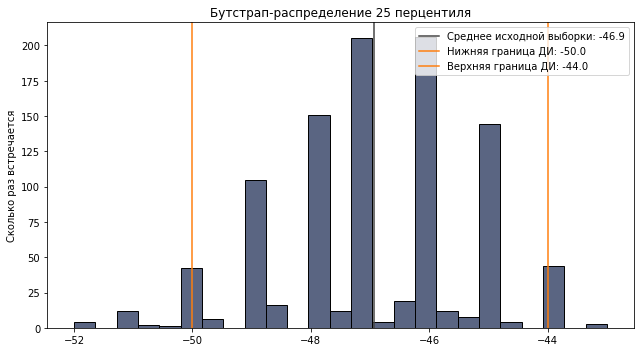

```python
boot_hist(result,25)
```

```python
result = boot_strap(control, test, 50)
```

```
'50%-й перцентиль контрольной группы: 118.00'
```

```
'50%-й перцентиль тестовой группы: 94.00'
```

```
'95%-й доверительный интервал разности 50-х перцентилей [-27.01, -19.00]'
```

```
'ДИ: [-27.01, -19.00]'
```

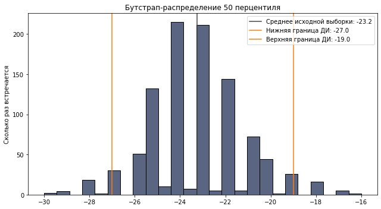

```python
boot_hist(result, 50)
```

```python
result = boot_strap(control, test, 75)
```

```
'75%-й перцентиль контрольной группы: 159.00'
```

```
'75%-й перцентиль тестовой группы: 179.50'
```

```
'95%-й доверительный интервал разности 75-х перцентилей [11.00, 30.00]'
```

```
'ДИ: [11.00, 30.00]'
```

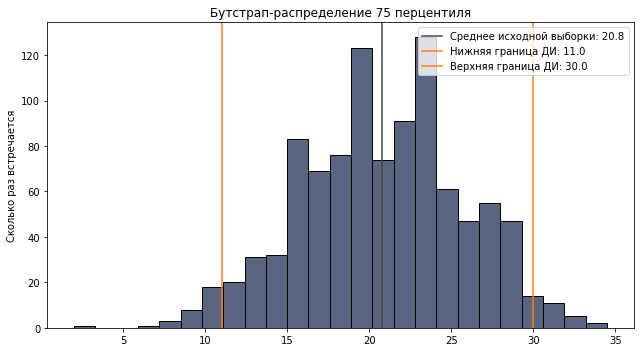

```python
boot_hist(result, 75)
```

**Вывод:** Анализ бутстрап-распределения 25, 50, 75 процентилей суммы всех депозитов на платящего пользователя показал, что доверительный интервал для разности (test − control) для 25 и 50 протентилей лежит ниже нуля (и не пересекает 0), что указывает на статистически значимое сокращение количества таких пользователей в тестовой группе.

Доверительный интервал 75 процентиля блольше больше нуля (и не пересекает 0), что говорит об увеличении количества пользователей бОльшей суммой на инвестиции в тестовой группе.

Т.е. в тестовой группе, по сравнению с контрольной, уменьшилось количество пользователей, инвестирующих небольшие суммы, но увеличилось количество пользователей, которые вкладывают суммы, больше средней.